# ANCOVA in TDE - Escrita (TDE - Escrita)

Geiser C. Challco geiser@alumni.usp.br

- Descriptive Statistics of Initial Data
- ANCOVA and Pairwise for one factor: **grupo**
  - Without remove non-normal data
  - Computing ANCOVA and PairWise After removing non-normal data (OK)
    - Plots for ancova
    - Checking linearity assumption
    - Checking normality and homogeneity
- ANCOVA and Pairwise for two factors **grupo:Sexo**
  - Without remove non-normal data
  - Computing ANCOVA and PairWise After removing non-normal data (OK)
    - Plots for ancova
    - Checking linearity assumption
    - Checking normality and homogeneity
- ANCOVA and Pairwise for two factors **grupo:Zona**
  - Without remove non-normal data
  - Computing ANCOVA and PairWise After removing non-normal data (OK)
    - Plots for ancova
    - Checking linearity assumption
    - Checking normality and homogeneity
- ANCOVA and Pairwise for two factors **grupo:Cor.Raca**
  - Without remove non-normal data
  - Computing ANCOVA and PairWise After removing non-normal data (OK)
    - Plots for ancova
    - Checking linearity assumption
    - Checking normality and homogeneity
- ANCOVA and Pairwise for two factors **grupo:Serie**
  - Without remove non-normal data
  - Computing ANCOVA and PairWise After removing non-normal data (OK)
    - Plots for ancova
    - Checking linearity assumption
    - Checking normality and homogeneity
- Summary of Results
  - Descriptive Statistics
  - ANCOVA Table Comparison
  - PairWise Table Comparison
  - EMMS Table Comparison

**NOTE**:

- Teste ANCOVA para determinar se houve diferenças significativas no TDE - Escrita (medido usando pre- e pos-testes).
- ANCOVA test to determine whether there were significant differences in TDE - Escrita (measured using pre- and post-tests).

# Descriptive Statistics of Initial Data

```r
df <- get.descriptives(dat, c(dv.pre, dv.pos), c("grupo"),
                       include.global = T, symmetry.test = T, normality.test = F)
df <- plyr::rbind.fill(
  df, do.call(plyr::rbind.fill, lapply(lfatores2, FUN = function(f) {
    if (nrow(dat) > 0 && sum(!is.na(unique(dat[[f]]))) > 1)
      get.descriptives(dat, c(dv.pre,dv.pos), c("grupo", f),
                       symmetry.test = T, normality.test = F)
    }))
)
(df <- df[,c(fatores1[fatores1 %in% colnames(df)],"variable",
             colnames(df)[!colnames(df) %in% c(fatores1,"variable")])])
```

```
##           grupo Sexo   Zona Cor.Raca Serie      variable   n   mean median min max     sd    se     ci
## 1      Controle <NA>   <NA>     <NA>  <NA> score.tde.pre 124 58.621   58.0  52  75  5.367 0.482  0.954
## 2  Experimental <NA>   <NA>     <NA>  <NA> score.tde.pre 134 58.336   57.5  52  73  5.029 0.434  0.859
## 3          <NA> <NA>   <NA>     <NA>  <NA> score.tde.pre 258 58.473   58.0  52  75  5.186 0.323  0.636
## 4      Controle <NA>   <NA>     <NA>  <NA> score.tde.pos 124 54.806   56.0  22  73 10.905 0.979  1.938
## 5  Experimental <NA>   <NA>     <NA>  <NA> score.tde.pos 134 55.791   57.0  14  74 10.619 0.917  1.814
## 6          <NA> <NA>   <NA>     <NA>  <NA> score.tde.pos 258 55.318   56.0  14  74 10.748 0.669  1.318
## 7      Controle    F   <NA>     <NA>  <NA> score.tde.pre  72 58.028   57.0  52  72  4.887 0.576  1.148
## 8      Controle    M   <NA>     <NA>  <NA> score.tde.pre  52 59.442   58.0  52  75  5.919 0.821  1.648
## 9  Experimental    F   <NA>     <NA>  <NA> score.tde.pre  86 58.395   58.0  52  73  4.990 0.538  1.070
## 10 Experimental    M   <NA>     <NA>  <NA> score.tde.pre  48 58.229   57.0  52  71  5.150 0.743  1.495
## 11     Controle    F   <NA>     <NA>  <NA> score.tde.pos  72 54.500   55.5  24  72  9.710 1.144  2.282
## 12     Controle    M   <NA>     <NA>  <NA> score.tde.pos  52 55.231   57.5  22  73 12.460 1.728  3.469
## 13 Experimental    F   <NA>     <NA>  <NA> score.tde.pos  86 56.651   58.0  14  73 10.095 1.089  2.164
## 14 Experimental    M   <NA>     <NA>  <NA> score.tde.pos  48 54.250   55.5  22  74 11.446 1.652  3.323
```

[output cut: 98 more lines]

| grupo | Sexo | Zona | Cor.Raca | Serie | variable | n | mean | median | min | max | sd | se | ci | iqr | symmetry | skewness | kurtosis |
| --- | --- | --- | --- | --- | --- | --- | --- | --- | --- | --- | --- | --- | --- | --- | --- | --- | --- |
| Controle |  |  |  |  | score.tde.pre | 124 | 58.621 | 58.0 | 52 | 75 | 5.367 | 0.482 | 0.954 | 8.00 | NO | 0.794 | 0.036 |
| Experimental |  |  |  |  | score.tde.pre | 134 | 58.336 | 57.5 | 52 | 73 | 5.029 | 0.434 | 0.859 | 8.00 | NO | 0.688 | -0.352 |
|  |  |  |  |  | score.tde.pre | 258 | 58.473 | 58.0 | 52 | 75 | 5.186 | 0.323 | 0.636 | 8.00 | NO | 0.754 | -0.091 |
| Controle |  |  |  |  | score.tde.pos | 124 | 54.806 | 56.0 | 22 | 73 | 10.905 | 0.979 | 1.938 | 11.25 | NO | -0.916 | 0.870 |
| Experimental |  |  |  |  | score.tde.pos | 134 | 55.791 | 57.0 | 14 | 74 | 10.619 | 0.917 | 1.814 | 12.00 | NO | -1.174 | 2.100 |
|  |  |  |  |  | score.tde.pos | 258 | 55.318 | 56.0 | 14 | 74 | 10.748 | 0.669 | 1.318 | 12.00 | NO | -1.052 | 1.492 |
| Controle | F |  |  |  | score.tde.pre | 72 | 58.028 | 57.0 | 52 | 72 | 4.887 | 0.576 | 1.148 | 7.25 | NO | 0.569 | -0.449 |
| Controle | M |  |  |  | score.tde.pre | 52 | 59.442 | 58.0 | 52 | 75 | 5.919 | 0.821 | 1.648 | 8.25 | NO | 0.838 | -0.205 |
| Experimental | F |  |  |  | score.tde.pre | 86 | 58.395 | 58.0 | 52 | 73 | 4.990 | 0.538 | 1.070 | 7.75 | NO | 0.682 | -0.319 |
| Experimental | M |  |  |  | score.tde.pre | 48 | 58.229 | 57.0 | 52 | 71 | 5.150 | 0.743 | 1.495 | 8.00 | NO | 0.681 | -0.510 |
| Controle | F |  |  |  | score.tde.pos | 72 | 54.500 | 55.5 | 24 | 72 | 9.710 | 1.144 | 2.282 | 10.25 | NO | -0.935 | 1.331 |
| Controle | M |  |  |  | score.tde.pos | 52 | 55.231 | 57.5 | 22 | 73 | 12.460 | 1.728 | 3.469 | 13.00 | NO | -0.891 | 0.254 |
| Experimental | F |  |  |  | score.tde.pos | 86 | 56.651 | 58.0 | 14 | 73 | 10.095 | 1.089 | 2.164 | 11.75 | NO | -1.386 | 3.293 |
| Experimental | M |  |  |  | score.tde.pos | 48 | 54.250 | 55.5 | 22 | 74 | 11.446 | 1.652 | 3.323 | 13.25 | NO | -0.828 | 0.637 |
| Controle |  | Rural |  |  | score.tde.pre | 53 | 58.264 | 57.0 | 52 | 69 | 4.772 | 0.656 | 1.315 | 8.00 | YES | 0.498 | -0.806 |
| Controle |  | Urbana |  |  | score.tde.pre | 29 | 59.966 | 58.0 | 52 | 75 | 6.293 | 1.169 | 2.394 | 8.00 | NO | 0.862 | -0.353 |
| Controle |  |  |  |  | score.tde.pre | 42 | 58.143 | 57.5 | 52 | 73 | 5.367 | 0.828 | 1.673 | 8.00 | NO | 0.700 | -0.237 |
| Experimental |  | Rural |  |  | score.tde.pre | 52 | 58.827 | 58.0 | 52 | 73 | 5.276 | 0.732 | 1.469 | 7.00 | NO | 0.664 | -0.404 |
| Experimental |  | Urbana |  |  | score.tde.pre | 37 | 57.865 | 58.0 | 52 | 71 | 5.045 | 0.829 | 1.682 | 7.00 | NO | 0.702 | -0.347 |
| Experimental |  |  |  |  | score.tde.pre | 45 | 58.156 | 57.0 | 52 | 69 | 4.781 | 0.713 | 1.436 | 8.00 | NO | 0.623 | -0.709 |
| Controle |  | Rural |  |  | score.tde.pos | 53 | 56.491 | 57.0 | 24 | 72 | 9.549 | 1.312 | 2.632 | 12.00 | NO | -0.910 | 1.297 |
| Controle |  | Urbana |  |  | score.tde.pos | 29 | 53.103 | 55.0 | 28 | 73 | 10.814 | 2.008 | 4.114 | 11.00 | YES | -0.345 | -0.270 |
| Controle |  |  |  |  | score.tde.pos | 42 | 53.857 | 56.0 | 22 | 73 | 12.434 | 1.919 | 3.875 | 10.75 | NO | -1.015 | 0.508 |
| Experimental |  | Rural |  |  | score.tde.pos | 52 | 56.077 | 58.0 | 22 | 72 | 11.998 | 1.664 | 3.340 | 14.00 | NO | -1.176 | 1.025 |
| Experimental |  | Urbana |  |  | score.tde.pos | 37 | 54.108 | 55.0 | 38 | 74 | 8.517 | 1.400 | 2.840 | 10.00 | YES | 0.082 | -0.317 |
| Experimental |  |  |  |  | score.tde.pos | 45 | 56.844 | 58.0 | 14 | 73 | 10.536 | 1.571 | 3.165 | 11.00 | NO | -1.768 | 4.707 |
| Controle |  |  | Branca |  | score.tde.pre | 11 | 60.000 | 61.0 | 52 | 67 | 4.712 | 1.421 | 3.165 | 4.00 | YES | -0.459 | -0.909 |
| Controle |  |  | Indígena |  | score.tde.pre | 3 | 56.667 | 53.0 | 52 | 65 | 7.234 | 4.177 | 17.971 | 6.50 | few data | 0.000 | 0.000 |
| Controle |  |  | Parda |  | score.tde.pre | 35 | 57.286 | 57.0 | 52 | 66 | 3.900 | 0.659 | 1.340 | 5.50 | YES | 0.493 | -0.733 |
| Controle |  |  |  |  | score.tde.pre | 75 | 59.120 | 58.0 | 52 | 75 | 5.911 | 0.683 | 1.360 | 9.00 | NO | 0.791 | -0.271 |
| Experimental |  |  | Branca |  | score.tde.pre | 13 | 61.385 | 61.0 | 54 | 73 | 5.561 | 1.542 | 3.360 | 6.00 | NO | 0.605 | -0.770 |
| Experimental |  |  | Indígena |  | score.tde.pre | 2 | 53.500 | 53.5 | 53 | 54 | 0.707 | 0.500 | 6.353 | 0.50 | few data | 0.000 | 0.000 |
| Experimental |  |  | Parda |  | score.tde.pre | 35 | 58.143 | 58.0 | 52 | 68 | 5.214 | 0.881 | 1.791 | 8.00 | YES | 0.448 | -1.073 |
| Experimental |  |  |  |  | score.tde.pre | 84 | 58.060 | 57.0 | 52 | 71 | 4.775 | 0.521 | 1.036 | 8.00 | NO | 0.736 | -0.298 |
| Controle |  |  | Branca |  | score.tde.pos | 11 | 55.273 | 59.0 | 22 | 72 | 13.342 | 4.023 | 8.964 | 11.00 | NO | -1.208 | 0.822 |
| Controle |  |  | Indígena |  | score.tde.pos | 3 | 60.333 | 63.0 | 55 | 63 | 4.619 | 2.667 | 11.474 | 4.00 | few data | 0.000 | 0.000 |
| Controle |  |  | Parda |  | score.tde.pos | 35 | 52.086 | 54.0 | 24 | 68 | 10.354 | 1.750 | 3.557 | 9.50 | NO | -0.994 | 0.336 |
| Controle |  |  |  |  | score.tde.pos | 75 | 55.787 | 56.0 | 24 | 73 | 10.864 | 1.255 | 2.500 | 11.50 | NO | -0.791 | 0.659 |
| Experimental |  |  | Branca |  | score.tde.pos | 13 | 59.923 | 58.0 | 49 | 72 | 8.046 | 2.232 | 4.862 | 13.00 | YES | 0.300 | -1.516 |
| Experimental |  |  | Indígena |  | score.tde.pos | 2 | 54.500 | 54.5 | 52 | 57 | 3.536 | 2.500 | 31.766 | 2.50 | few data | 0.000 | 0.000 |
| Experimental |  |  | Parda |  | score.tde.pos | 35 | 52.943 | 55.0 | 14 | 71 | 14.582 | 2.465 | 5.009 | 17.00 | NO | -1.001 | 0.136 |
| Experimental |  |  |  |  | score.tde.pos | 84 | 56.369 | 57.0 | 24 | 74 | 8.808 | 0.961 | 1.912 | 12.00 | NO | -0.711 | 0.987 |
| Controle |  |  |  | 6 ano | score.tde.pre | 16 | 56.938 | 56.5 | 52 | 63 | 3.820 | 0.955 | 2.036 | 5.75 | YES | 0.280 | -1.409 |
| Controle |  |  |  | 7 ano | score.tde.pre | 23 | 57.957 | 57.0 | 52 | 69 | 4.477 | 0.934 | 1.936 | 5.50 | NO | 0.623 | -0.400 |
| Controle |  |  |  | 8 ano | score.tde.pre | 28 | 58.429 | 57.5 | 52 | 72 | 5.561 | 1.051 | 2.156 | 7.25 | NO | 0.651 | -0.577 |
| Controle |  |  |  | 9 ano | score.tde.pre | 57 | 59.456 | 58.0 | 52 | 75 | 5.904 | 0.782 | 1.567 | 8.00 | NO | 0.697 | -0.330 |
| Experimental |  |  |  | 6 ano | score.tde.pre | 13 | 56.385 | 56.0 | 52 | 65 | 3.754 | 1.041 | 2.268 | 3.00 | NO | 0.935 | -0.190 |
| Experimental |  |  |  | 7 ano | score.tde.pre | 30 | 57.933 | 57.0 | 52 | 68 | 4.502 | 0.822 | 1.681 | 8.00 | YES | 0.347 | -1.098 |
| Experimental |  |  |  | 8 ano | score.tde.pre | 41 | 58.146 | 57.0 | 52 | 73 | 5.512 | 0.861 | 1.740 | 6.00 | NO | 0.924 | -0.002 |
| Experimental |  |  |  | 9 ano | score.tde.pre | 50 | 59.240 | 58.5 | 52 | 71 | 5.141 | 0.727 | 1.461 | 7.75 | YES | 0.402 | -0.909 |
| Controle |  |  |  | 6 ano | score.tde.pos | 16 | 52.500 | 54.0 | 28 | 66 | 9.359 | 2.340 | 4.987 | 7.75 | NO | -0.940 | 0.728 |
| Controle |  |  |  | 7 ano | score.tde.pos | 23 | 51.696 | 56.0 | 22 | 72 | 14.968 | 3.121 | 6.473 | 12.00 | NO | -0.878 | -0.433 |
| Controle |  |  |  | 8 ano | score.tde.pos | 28 | 55.071 | 56.0 | 32 | 71 | 9.116 | 1.723 | 3.535 | 9.25 | YES | -0.460 | -0.277 |
| Controle |  |  |  | 9 ano | score.tde.pos | 57 | 56.579 | 58.0 | 31 | 73 | 10.046 | 1.331 | 2.666 | 12.00 | NO | -0.583 | -0.086 |
| Experimental |  |  |  | 6 ano | score.tde.pos | 13 | 52.923 | 52.0 | 40 | 65 | 9.535 | 2.644 | 5.762 | 18.00 | YES | -0.067 | -1.780 |
| Experimental |  |  |  | 7 ano | score.tde.pos | 30 | 51.167 | 54.0 | 22 | 67 | 11.841 | 2.162 | 4.422 | 11.75 | NO | -0.826 | 0.048 |
| Experimental |  |  |  | 8 ano | score.tde.pos | 41 | 58.659 | 59.0 | 39 | 73 | 8.302 | 1.297 | 2.621 | 13.00 | YES | -0.336 | -0.655 |
| Experimental |  |  |  | 9 ano | score.tde.pos | 50 | 56.960 | 57.0 | 14 | 74 | 10.999 | 1.555 | 3.126 | 8.75 | NO | -1.730 | 4.357 |

# ANCOVA and Pairwise for one factor: **grupo**

## Without remove non-normal data

```r
pdat = remove_group_data(dat[!is.na(dat[["grupo"]]),], "score.tde.pos", "grupo")

pdat.long <- rbind(pdat[,c("id","grupo")], pdat[,c("id","grupo")])
pdat.long[["time"]] <- c(rep("pre", nrow(pdat)), rep("pos", nrow(pdat)))
pdat.long[["time"]] <- factor(pdat.long[["time"]], c("pre","pos"))
pdat.long[["score.tde"]] <- c(pdat[["score.tde.pre"]], pdat[["score.tde.pos"]])

aov = anova_test(pdat, score.tde.pos ~ score.tde.pre + grupo)
laov[["grupo"]] <- get_anova_table(aov)
```

```r
pwc <- emmeans_test(pdat, score.tde.pos ~ grupo, covariate = score.tde.pre,
                    p.adjust.method = "bonferroni")
```

```r
pwc.long <- emmeans_test(dplyr::group_by_at(pdat.long, "grupo"),
                          score.tde ~ time,
                          p.adjust.method = "bonferroni")
lpwc[["grupo"]] <- plyr::rbind.fill(pwc, pwc.long)
```

```r
ds <- get.descriptives(pdat, "score.tde.pos", "grupo", covar = "score.tde.pre")
ds <- merge(ds[ds$variable != "score.tde.pre",],
            ds[ds$variable == "score.tde.pre", !colnames(ds) %in% c("variable")],
            by = "grupo", all.x = T, suffixes = c("", ".score.tde.pre"))
ds <- merge(get_emmeans(pwc), ds, by = "grupo", suffixes = c(".emms", ""))
ds <- ds[,c("grupo","n","mean.score.tde.pre","se.score.tde.pre","mean","se","emmean","se.emms")]

colnames(ds) <- c("grupo", "N", paste0(c("M","SE")," (pre)"),
                  paste0(c("M","SE"), " (unadj)"), paste0(c("M", "SE"), " (adj)"))

lemms[["grupo"]] <- ds
```

```r
wdat = pdat

res = residuals(lm(score.tde.pos ~ score.tde.pre + grupo, data = wdat))
non.normal = getNonNormal(res, wdat$id, plimit = 0.05)

wdat = wdat[!wdat$id %in% non.normal,]

wdat.long <- rbind(wdat[,c("id","grupo")], wdat[,c("id","grupo")])
wdat.long[["time"]] <- c(rep("pre", nrow(wdat)), rep("pos", nrow(wdat)))
wdat.long[["time"]] <- factor(wdat.long[["time"]], c("pre","pos"))
wdat.long[["score.tde"]] <- c(wdat[["score.tde.pre"]], wdat[["score.tde.pos"]])

ldat[["grupo"]] = wdat

(non.normal)
```

```
##  [1] "P1128" "P1117" "P3019" "P1018" "P2959" "P908"  "P3054" "P3021" "P3228" "P2910" "P3005" "P2961"
## [13] "P1149" "P3545" "P2952" "P3050" "P1118" "P1825" "P3703" "P1152"
```

```r
aov = anova_test(wdat, score.tde.pos ~ score.tde.pre + grupo)
laov[["grupo"]] <- merge(get_anova_table(aov), laov[["grupo"]], by="Effect", suffixes = c("","'"))

(df = get_anova_table(aov))
```

```
## ANOVA Table (type II tests)
##
##          Effect DFn DFd       F        p p<.05   ges
## 1 score.tde.pre   1 235 171.552 8.52e-30     * 0.422
## 2         grupo   1 235   1.964 1.62e-01       0.008
```

| Effect | DFn | DFd | F | p | p<.05 | ges |
| --- | --- | --- | --- | --- | --- | --- |
| score.tde.pre | 1 | 235 | 171.552 | 0.000 | * | 0.422 |
| grupo | 1 | 235 | 1.964 | 0.162 |  | 0.008 |

[output not shown]

```r
pwc.long <- emmeans_test(dplyr::group_by_at(wdat.long, "grupo"),
                         score.tde ~ time,
                         p.adjust.method = "bonferroni")
lpwc[["grupo"]] <- merge(plyr::rbind.fill(pwc, pwc.long), lpwc[["grupo"]], by=c("grupo","term",".y.","group1","group2"), suffixes = c("","'"))
```

| grupo | term | .y. | group1 | group2 | df | statistic | p | p.adj | p.adj.signif |
| --- | --- | --- | --- | --- | --- | --- | --- | --- | --- |
| Controle | time | score.tde | pre | pos | 472 | 2.038 | 0.042 | 0.042 | * |
| Experimental | time | score.tde | pre | pos | 472 | 0.831 | 0.407 | 0.407 | ns |

```r
ds <- get.descriptives(wdat, "score.tde.pos", "grupo", covar = "score.tde.pre")
ds <- merge(ds[ds$variable != "score.tde.pre",],
            ds[ds$variable == "score.tde.pre", !colnames(ds) %in% c("variable")],
            by = "grupo", all.x = T, suffixes = c("", ".score.tde.pre"))
ds <- merge(get_emmeans(pwc), ds, by = "grupo", suffixes = c(".emms", ""))
ds <- ds[,c("grupo","n","mean.score.tde.pre","se.score.tde.pre","mean","se","emmean","se.emms")]

colnames(ds) <- c("grupo", "N", paste0(c("M","SE")," (pre)"),
                  paste0(c("M","SE"), " (unadj)"), paste0(c("M", "SE"), " (adj)"))

lemms[["grupo"]] <- merge(ds, lemms[["grupo"]], by=c("grupo"), suffixes = c("","'"))
```

| grupo | N | M (pre) | SE (pre) | M (unadj) | SE (unadj) | M (adj) | SE (adj) |
| --- | --- | --- | --- | --- | --- | --- | --- |
| Controle | 114 | 58.825 | 0.512 | 57.009 | 0.757 | 56.826 | 0.567 |
| Experimental | 124 | 58.468 | 0.450 | 57.758 | 0.701 | 57.926 | 0.544 |

### Plots for ancova

```r
plots <- oneWayAncovaPlots(
  wdat, "score.tde.pos", "grupo", aov, list("grupo"=pwc), addParam = c("mean_se"),
  font.label.size=10, step.increase=0.05, p.label="p.adj",
  subtitle = which(aov$Effect == "grupo"))
```

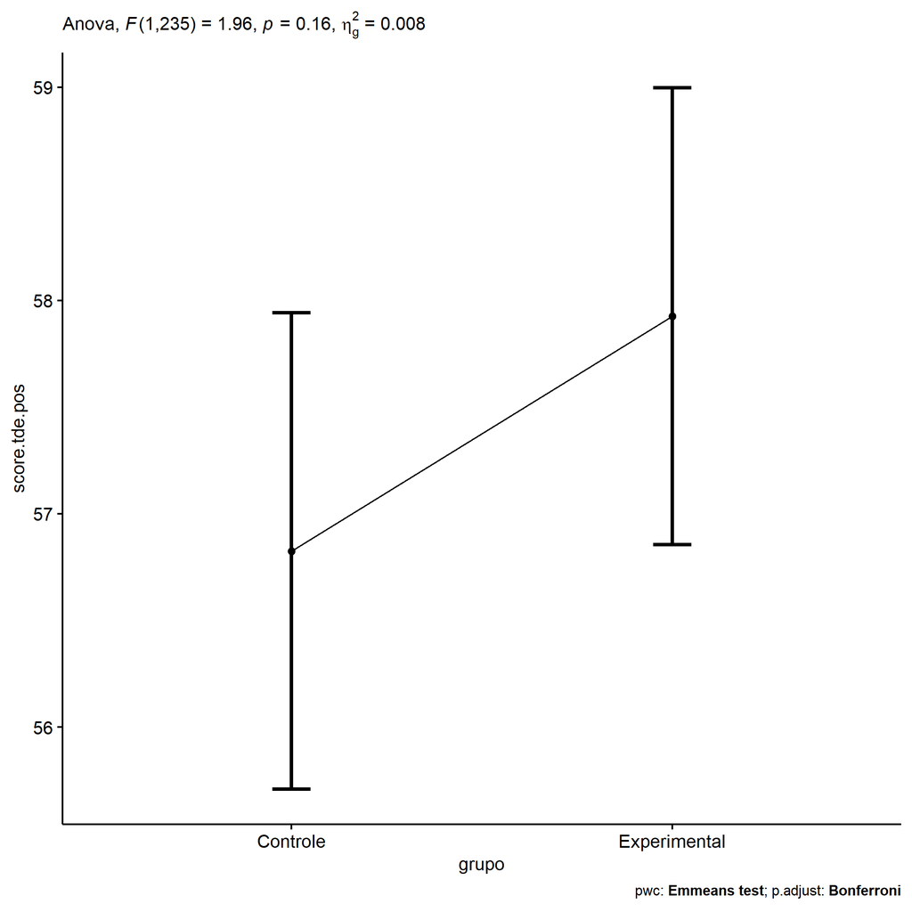

```r
if (!is.null(nrow(plots[["grupo"]]$data)))
  plots[["grupo"]] + ggplot2::scale_color_manual(values = color[["grupo"]])
```

```r
plots <- oneWayAncovaBoxPlots(
  wdat, "score.tde.pos", "grupo", aov, pwc, covar = "score.tde.pre",
  theme = "classic", color = color[["grupo"]],
  subtitle = which(aov$Effect == "grupo"))
```

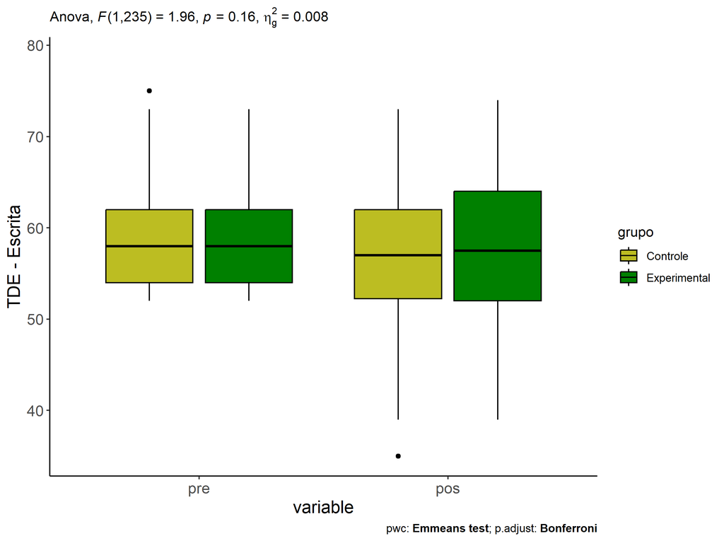

```r
if (length(unique(wdat[["grupo"]])) > 1)
  plots[["grupo"]] + ggplot2::ylab("TDE - Escrita") + ggplot2::scale_x_discrete(labels=c('pre', 'pos'))
```

```r
if (length(unique(wdat.long[["grupo"]])) > 1)
  plots <- oneWayAncovaBoxPlots(
    wdat.long, "score.tde", "grupo", aov, pwc.long, pre.post = "time",
    theme = "classic", color = color$prepost)
```

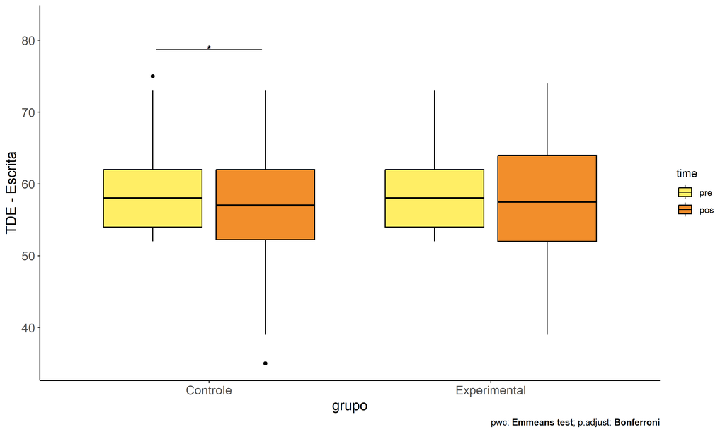

```r
if (length(unique(wdat.long[["grupo"]])) > 1)
  plots[["grupo"]] + ggplot2::ylab("TDE - Escrita")
```

### Checking linearity assumption

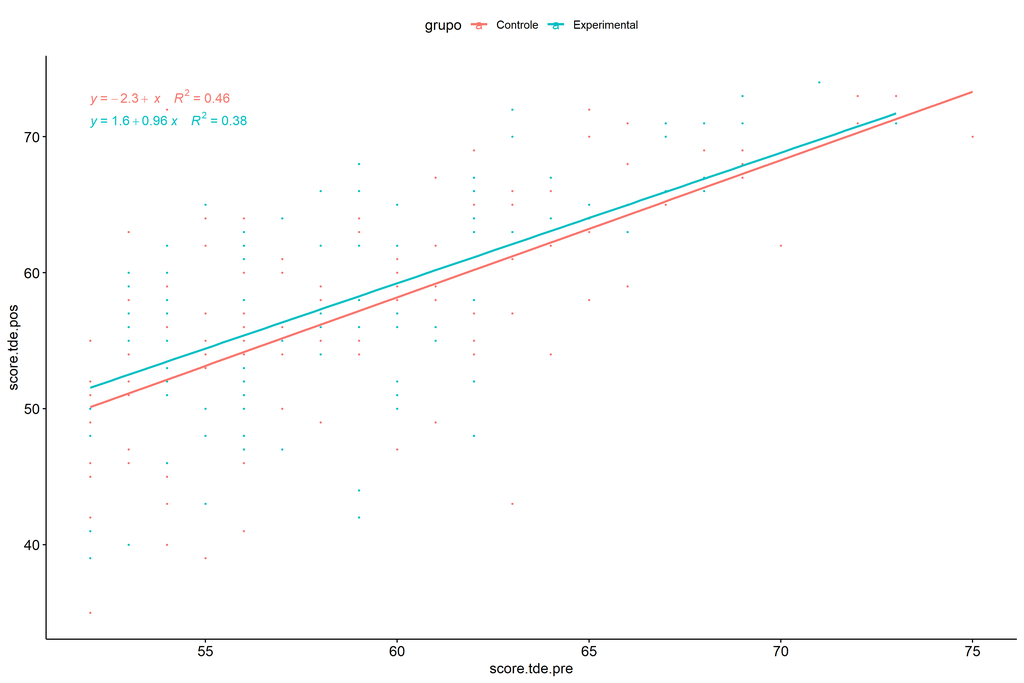

```r
ggscatter(wdat, x = "score.tde.pre", y = "score.tde.pos", size = 0.5,
          color = "grupo", add = "reg.line")+
  stat_regline_equation(
    aes(label =  paste(..eq.label.., ..rr.label.., sep = "~~~~"), color = grupo)
  )
```

### Checking normality and homogeneity

```r
res <- augment(lm(score.tde.pos ~ score.tde.pre + grupo, data = wdat))
```

```r
shapiro_test(res$.resid)
```

```
## # A tibble: 1 × 3
##   variable   statistic p.value
##   <chr>          <dbl>   <dbl>
## 1 res$.resid     0.982 0.00415
```

```r
levene_test(res, .resid ~ grupo)
```

```
## # A tibble: 1 × 4
##     df1   df2 statistic     p
##   <int> <int>     <dbl> <dbl>
## 1     1   236      1.25 0.264
```

# ANCOVA and Pairwise for two factors **grupo:Sexo**

## Without remove non-normal data

```r
pdat = remove_group_data(dat[!is.na(dat[["grupo"]]) & !is.na(dat[["Sexo"]]),], "score.tde.pos", c("grupo","Sexo"))

pdat.long <- rbind(pdat[,c("id","grupo","Sexo")], pdat[,c("id","grupo","Sexo")])
pdat.long[["time"]] <- c(rep("pre", nrow(pdat)), rep("pos", nrow(pdat)))
pdat.long[["time"]] <- factor(pdat.long[["time"]], c("pre","pos"))
pdat.long[["score.tde"]] <- c(pdat[["score.tde.pre"]], pdat[["score.tde.pos"]])

aov = anova_test(pdat, score.tde.pos ~ score.tde.pre + grupo*Sexo)
laov[["grupo:Sexo"]] <- get_anova_table(aov)
```

```r
pwcs <- list()
pwcs[["Sexo"]] <- emmeans_test(
  group_by(pdat, grupo), score.tde.pos ~ Sexo,
  covariate = score.tde.pre, p.adjust.method = "bonferroni")
pwcs[["grupo"]] <- emmeans_test(
  group_by(pdat, Sexo), score.tde.pos ~ grupo,
  covariate = score.tde.pre, p.adjust.method = "bonferroni")

pwc <- plyr::rbind.fill(pwcs[["grupo"]], pwcs[["Sexo"]])
pwc <- pwc[,c("grupo","Sexo", colnames(pwc)[!colnames(pwc) %in% c("grupo","Sexo")])]
```

```r
pwc.long <- emmeans_test(dplyr::group_by_at(pdat.long, c("grupo","Sexo")),
                         score.tde ~ time,
                         p.adjust.method = "bonferroni")
lpwc[["grupo:Sexo"]] <- plyr::rbind.fill(pwc, pwc.long)
```

```r
ds <- get.descriptives(pdat, "score.tde.pos", c("grupo","Sexo"), covar = "score.tde.pre")
ds <- merge(ds[ds$variable != "score.tde.pre",],
            ds[ds$variable == "score.tde.pre", !colnames(ds) %in% c("variable")],
            by = c("grupo","Sexo"), all.x = T, suffixes = c("", ".score.tde.pre"))
ds <- merge(get_emmeans(pwcs[["grupo"]]), ds, by = c("grupo","Sexo"), suffixes = c(".emms", ""))
ds <- ds[,c("grupo","Sexo","n","mean.score.tde.pre","se.score.tde.pre","mean","se","emmean","se.emms")]

colnames(ds) <- c("grupo","Sexo", "N", paste0(c("M","SE")," (pre)"),
                  paste0(c("M","SE"), " (unadj)"), paste0(c("M", "SE"), " (adj)"))

lemms[["grupo:Sexo"]] <- ds
```

```r
wdat = pdat

res = residuals(lm(score.tde.pos ~ score.tde.pre + grupo*Sexo, data = wdat))
non.normal = getNonNormal(res, wdat$id, plimit = 0.05)

wdat = wdat[!wdat$id %in% non.normal,]

wdat.long <- rbind(wdat[,c("id","grupo","Sexo")], wdat[,c("id","grupo","Sexo")])
wdat.long[["time"]] <- c(rep("pre", nrow(wdat)), rep("pos", nrow(wdat)))
wdat.long[["time"]] <- factor(wdat.long[["time"]], c("pre","pos"))
wdat.long[["score.tde"]] <- c(wdat[["score.tde.pre"]], wdat[["score.tde.pos"]])


ldat[["grupo:Sexo"]] = wdat

(non.normal)
```

```
##  [1] "P1128" "P3019" "P1117" "P3021" "P3054" "P2959" "P2910" "P3005" "P3228" "P1118" "P1018" "P908"
## [13] "P3050" "P1152" "P3703" "P3241" "P1149" "P2952" "P2961" "P1825"
```

```r
aov = anova_test(wdat, score.tde.pos ~ score.tde.pre + grupo*Sexo)
laov[["grupo:Sexo"]] <- merge(get_anova_table(aov), laov[["grupo:Sexo"]], by="Effect", suffixes = c("","'"))

(df = get_anova_table(aov))
```

```
## ANOVA Table (type II tests)
##
##          Effect DFn DFd       F        p p<.05   ges
## 1 score.tde.pre   1 233 181.900 5.02e-31     * 0.438
## 2         grupo   1 233   0.941 3.33e-01       0.004
## 3          Sexo   1 233   0.599 4.40e-01       0.003
## 4    grupo:Sexo   1 233   6.793 1.00e-02     * 0.028
```

| Effect | DFn | DFd | F | p | p<.05 | ges |
| --- | --- | --- | --- | --- | --- | --- |
| score.tde.pre | 1 | 233 | 181.900 | 0.000 | * | 0.438 |
| grupo | 1 | 233 | 0.941 | 0.333 |  | 0.004 |
| Sexo | 1 | 233 | 0.599 | 0.440 |  | 0.003 |
| grupo:Sexo | 1 | 233 | 6.793 | 0.010 | * | 0.028 |

```r
pwcs <- list()
pwcs[["Sexo"]] <- emmeans_test(
  group_by(wdat, grupo), score.tde.pos ~ Sexo,
  covariate = score.tde.pre, p.adjust.method = "bonferroni")
pwcs[["grupo"]] <- emmeans_test(
  group_by(wdat, Sexo), score.tde.pos ~ grupo,
  covariate = score.tde.pre, p.adjust.method = "bonferroni")

pwc <- plyr::rbind.fill(pwcs[["grupo"]], pwcs[["Sexo"]])
pwc <- pwc[,c("grupo","Sexo", colnames(pwc)[!colnames(pwc) %in% c("grupo","Sexo")])]
```

| grupo | Sexo | term | .y. | group1 | group2 | df | statistic | p | p.adj | p.adj.signif |
| --- | --- | --- | --- | --- | --- | --- | --- | --- | --- | --- |
|  | F | score.tde.pre*grupo | score.tde.pos | Controle | Experimental | 233 | -2.369 | 0.019 | 0.019 | * |
|  | M | score.tde.pre*grupo | score.tde.pos | Controle | Experimental | 233 | 1.457 | 0.146 | 0.146 | ns |
| Controle |  | score.tde.pre*Sexo | score.tde.pos | F | M | 233 | -1.335 | 0.183 | 0.183 | ns |
| Experimental |  | score.tde.pre*Sexo | score.tde.pos | F | M | 233 | 2.366 | 0.019 | 0.019 | * |

```r
pwc.long <- emmeans_test(dplyr::group_by_at(wdat.long, c("grupo","Sexo")),
                         score.tde ~ time,
                         p.adjust.method = "bonferroni")
lpwc[["grupo:Sexo"]] <- merge(plyr::rbind.fill(pwc, pwc.long), lpwc[["grupo:Sexo"]], by=c("grupo","Sexo","term",".y.","group1","group2"), suffixes = c("","'"))
```

| grupo | Sexo | term | .y. | group1 | group2 | df | statistic | p | p.adj | p.adj.signif |
| --- | --- | --- | --- | --- | --- | --- | --- | --- | --- | --- |
| Controle | F | time | score.tde | pre | pos | 468 | 1.962 | 0.050 | 0.050 | ns |
| Controle | M | time | score.tde | pre | pos | 468 | 0.498 | 0.619 | 0.619 | ns |
| Experimental | F | time | score.tde | pre | pos | 468 | -0.070 | 0.944 | 0.944 | ns |
| Experimental | M | time | score.tde | pre | pos | 468 | 1.805 | 0.072 | 0.072 | ns |

```r
ds <- get.descriptives(wdat, "score.tde.pos", c("grupo","Sexo"), covar = "score.tde.pre")
ds <- merge(ds[ds$variable != "score.tde.pre",],
            ds[ds$variable == "score.tde.pre", !colnames(ds) %in% c("variable")],
            by = c("grupo","Sexo"), all.x = T, suffixes = c("", ".score.tde.pre"))
ds <- merge(get_emmeans(pwcs[["grupo"]]), ds, by = c("grupo","Sexo"), suffixes = c(".emms", ""))
ds <- ds[,c("grupo","Sexo","n","mean.score.tde.pre","se.score.tde.pre","mean","se","emmean","se.emms")]

colnames(ds) <- c("grupo","Sexo", "N", paste0(c("M","SE")," (pre)"),
                  paste0(c("M","SE"), " (unadj)"), paste0(c("M", "SE"), " (adj)"))

lemms[["grupo:Sexo"]] <- merge(ds, lemms[["grupo:Sexo"]], by=c("grupo","Sexo"), suffixes = c("","'"))
```

| grupo | Sexo | N | M (pre) | SE (pre) | M (unadj) | SE (unadj) | M (adj) | SE (adj) |
| --- | --- | --- | --- | --- | --- | --- | --- | --- |
| Controle | F | 68 | 58.235 | 0.595 | 55.956 | 0.928 | 56.317 | 0.731 |
| Controle | M | 45 | 59.622 | 0.925 | 58.911 | 1.236 | 57.869 | 0.901 |
| Experimental | F | 80 | 58.325 | 0.560 | 58.400 | 0.824 | 58.671 | 0.674 |
| Experimental | M | 45 | 58.578 | 0.763 | 56.000 | 1.385 | 56.015 | 0.898 |

### Plots for ancova

```r
plots <- twoWayAncovaPlots(
  wdat, "score.tde.pos", c("grupo","Sexo"), aov, pwcs, addParam = c("mean_se"),
  font.label.size=10, step.increase=0.05, p.label="p.adj",
  subtitle = which(aov$Effect == "grupo:Sexo"))
```

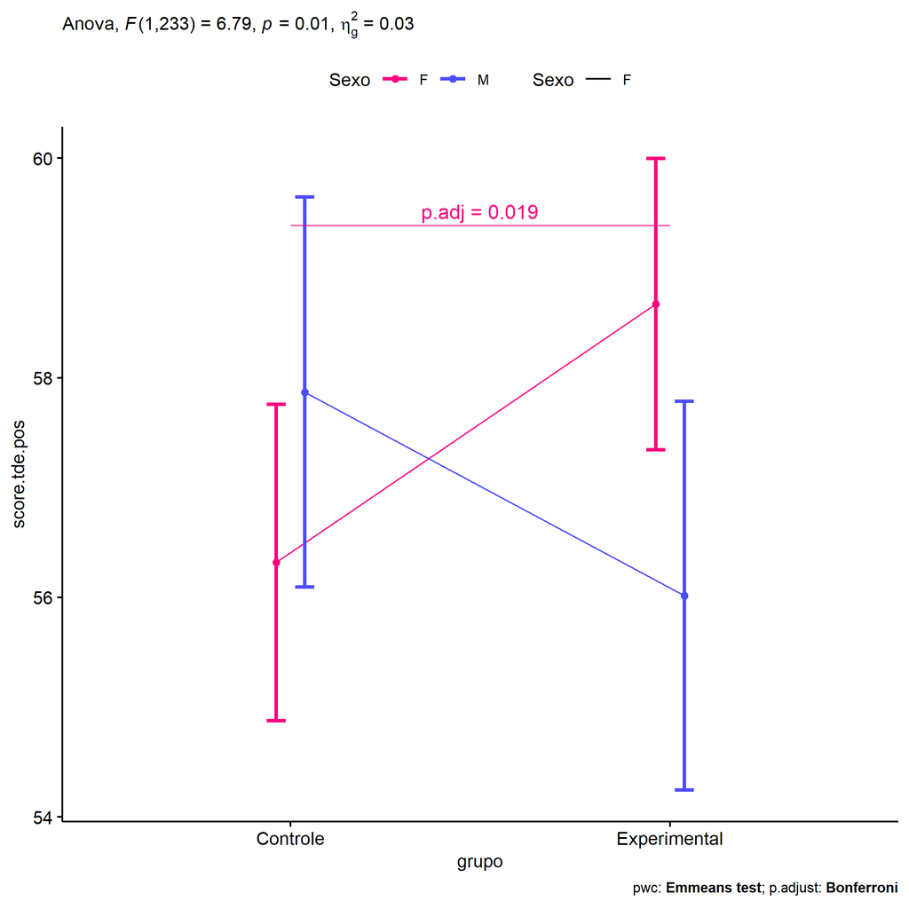

```r
if (!is.null(plots[["grupo"]]))
  plots[["grupo"]] + ggplot2::scale_color_manual(values = color[["Sexo"]])
```

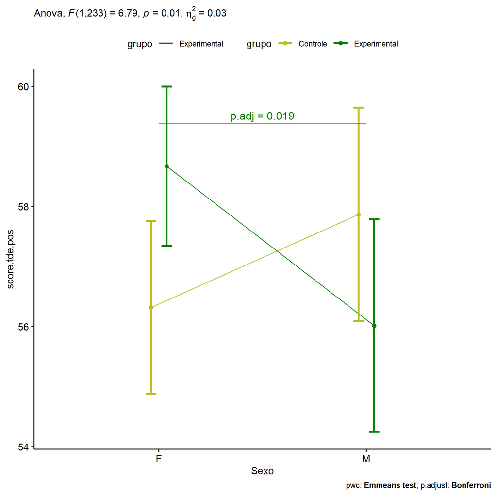

```r
if (!is.null(plots[["Sexo"]]))
  plots[["Sexo"]] + ggplot2::scale_color_manual(values = color[["grupo"]])
```

```r
plots <- twoWayAncovaBoxPlots(
  wdat, "score.tde.pos", c("grupo","Sexo"), aov, pwcs, covar = "score.tde.pre",
  theme = "classic", color = color[["grupo:Sexo"]],
  subtitle = which(aov$Effect == "grupo:Sexo"))
```

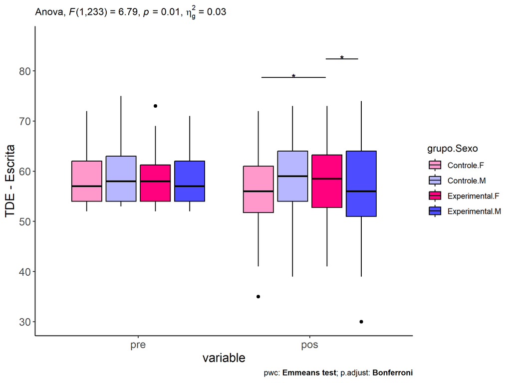

```r
plots[["grupo:Sexo"]] + ggplot2::ylab("TDE - Escrita") + ggplot2::scale_x_discrete(labels=c('pre', 'pos'))
```

```r
plots <- twoWayAncovaBoxPlots(
  wdat.long, "score.tde", c("grupo","Sexo"), aov, pwc.long, pre.post = "time",
  theme = "classic", color = color$prepost)
```

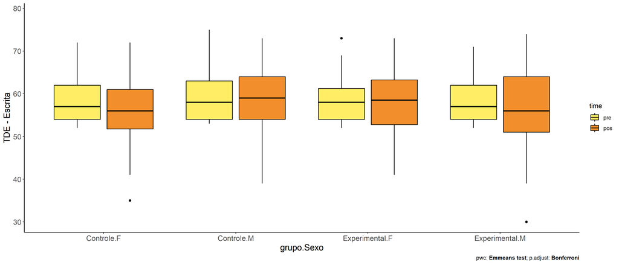

```r
plots[["grupo:Sexo"]] + ggplot2::ylab("TDE - Escrita")
```

### Checking linearity assumption

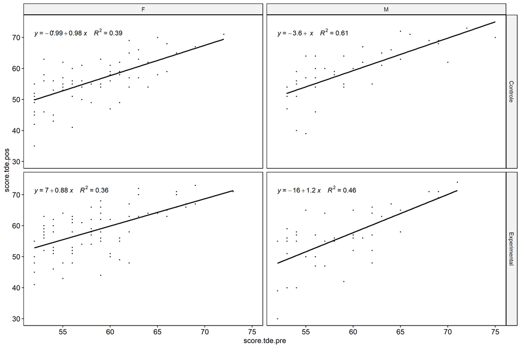

```r
ggscatter(wdat, x = "score.tde.pre", y = "score.tde.pos", size = 0.5,
          facet.by = c("grupo","Sexo"), add = "reg.line")+
  stat_regline_equation(
    aes(label =  paste(..eq.label.., ..rr.label.., sep = "~~~~"))
  )
```

### Checking normality and homogeneity

```r
res <- augment(lm(score.tde.pos ~ score.tde.pre + grupo*Sexo, data = wdat))
```

```r
shapiro_test(res$.resid)
```

```
## # A tibble: 1 × 3
##   variable   statistic p.value
##   <chr>          <dbl>   <dbl>
## 1 res$.resid     0.985  0.0111
```

```r
levene_test(res, .resid ~ grupo*Sexo)
```

```
## # A tibble: 1 × 4
##     df1   df2 statistic     p
##   <int> <int>     <dbl> <dbl>
## 1     3   234      1.76 0.155
```

# ANCOVA and Pairwise for two factors **grupo:Zona**

## Without remove non-normal data

```r
pdat = remove_group_data(dat[!is.na(dat[["grupo"]]) & !is.na(dat[["Zona"]]),], "score.tde.pos", c("grupo","Zona"))

pdat.long <- rbind(pdat[,c("id","grupo","Zona")], pdat[,c("id","grupo","Zona")])
pdat.long[["time"]] <- c(rep("pre", nrow(pdat)), rep("pos", nrow(pdat)))
pdat.long[["time"]] <- factor(pdat.long[["time"]], c("pre","pos"))
pdat.long[["score.tde"]] <- c(pdat[["score.tde.pre"]], pdat[["score.tde.pos"]])

aov = anova_test(pdat, score.tde.pos ~ score.tde.pre + grupo*Zona)
laov[["grupo:Zona"]] <- get_anova_table(aov)
```

```r
pwcs <- list()
pwcs[["Zona"]] <- emmeans_test(
  group_by(pdat, grupo), score.tde.pos ~ Zona,
  covariate = score.tde.pre, p.adjust.method = "bonferroni")
pwcs[["grupo"]] <- emmeans_test(
  group_by(pdat, Zona), score.tde.pos ~ grupo,
  covariate = score.tde.pre, p.adjust.method = "bonferroni")

pwc <- plyr::rbind.fill(pwcs[["grupo"]], pwcs[["Zona"]])
pwc <- pwc[,c("grupo","Zona", colnames(pwc)[!colnames(pwc) %in% c("grupo","Zona")])]
```

```r
pwc.long <- emmeans_test(dplyr::group_by_at(pdat.long, c("grupo","Zona")),
                         score.tde ~ time,
                         p.adjust.method = "bonferroni")
lpwc[["grupo:Zona"]] <- plyr::rbind.fill(pwc, pwc.long)
```

```r
ds <- get.descriptives(pdat, "score.tde.pos", c("grupo","Zona"), covar = "score.tde.pre")
ds <- merge(ds[ds$variable != "score.tde.pre",],
            ds[ds$variable == "score.tde.pre", !colnames(ds) %in% c("variable")],
            by = c("grupo","Zona"), all.x = T, suffixes = c("", ".score.tde.pre"))
ds <- merge(get_emmeans(pwcs[["grupo"]]), ds, by = c("grupo","Zona"), suffixes = c(".emms", ""))
ds <- ds[,c("grupo","Zona","n","mean.score.tde.pre","se.score.tde.pre","mean","se","emmean","se.emms")]

colnames(ds) <- c("grupo","Zona", "N", paste0(c("M","SE")," (pre)"),
                  paste0(c("M","SE"), " (unadj)"), paste0(c("M", "SE"), " (adj)"))

lemms[["grupo:Zona"]] <- ds
```

## Computing ANCOVA and PairWise After removing non-normal data (OK)

```r
wdat = pdat

res = residuals(lm(score.tde.pos ~ score.tde.pre + grupo*Zona, data = wdat))
non.normal = getNonNormal(res, wdat$id, plimit = 0.05)

wdat = wdat[!wdat$id %in% non.normal,]

wdat.long <- rbind(wdat[,c("id","grupo","Zona")], wdat[,c("id","grupo","Zona")])
wdat.long[["time"]] <- c(rep("pre", nrow(wdat)), rep("pos", nrow(wdat)))
wdat.long[["time"]] <- factor(wdat.long[["time"]], c("pre","pos"))
wdat.long[["score.tde"]] <- c(wdat[["score.tde.pre"]], wdat[["score.tde.pos"]])


ldat[["grupo:Zona"]] = wdat

(non.normal)
```

```
## [1] "P3021" "P908"  "P1117" "P1018" "P2959" "P3545" "P1152" "P3228"
```

```r
aov = anova_test(wdat, score.tde.pos ~ score.tde.pre + grupo*Zona)
laov[["grupo:Zona"]] <- merge(get_anova_table(aov), laov[["grupo:Zona"]], by="Effect", suffixes = c("","'"))

(df = get_anova_table(aov))
```

```
## ANOVA Table (type II tests)
##
##          Effect DFn DFd       F        p p<.05   ges
## 1 score.tde.pre   1 158 100.583 1.26e-18     * 0.389
## 2         grupo   1 158   0.539 4.64e-01       0.003
## 3          Zona   1 158  17.258 5.33e-05     * 0.098
## 4    grupo:Zona   1 158   1.581 2.11e-01       0.010
```

| Effect | DFn | DFd | F | p | p<.05 | ges |
| --- | --- | --- | --- | --- | --- | --- |
| score.tde.pre | 1 | 158 | 100.583 | 0.000 | * | 0.389 |
| grupo | 1 | 158 | 0.539 | 0.464 |  | 0.003 |
| Zona | 1 | 158 | 17.258 | 0.000 | * | 0.098 |
| grupo:Zona | 1 | 158 | 1.581 | 0.211 |  | 0.010 |

```r
pwcs <- list()
pwcs[["Zona"]] <- emmeans_test(
  group_by(wdat, grupo), score.tde.pos ~ Zona,
  covariate = score.tde.pre, p.adjust.method = "bonferroni")
pwcs[["grupo"]] <- emmeans_test(
  group_by(wdat, Zona), score.tde.pos ~ grupo,
  covariate = score.tde.pre, p.adjust.method = "bonferroni")

pwc <- plyr::rbind.fill(pwcs[["grupo"]], pwcs[["Zona"]])
pwc <- pwc[,c("grupo","Zona", colnames(pwc)[!colnames(pwc) %in% c("grupo","Zona")])]
```

| grupo | Zona | term | .y. | group1 | group2 | df | statistic | p | p.adj | p.adj.signif |
| --- | --- | --- | --- | --- | --- | --- | --- | --- | --- | --- |
|  | Rural | score.tde.pre*grupo | score.tde.pos | Controle | Experimental | 158 | 0.222 | 0.824 | 0.824 | ns |
|  | Urbana | score.tde.pre*grupo | score.tde.pos | Controle | Experimental | 158 | -1.441 | 0.152 | 0.152 | ns |
| Controle |  | score.tde.pre*Zona | score.tde.pos | Rural | Urbana | 158 | 3.733 | 0.000 | 0.000 | *** |
| Experimental |  | score.tde.pre*Zona | score.tde.pos | Rural | Urbana | 158 | 2.174 | 0.031 | 0.031 | * |

```r
pwc.long <- emmeans_test(dplyr::group_by_at(wdat.long, c("grupo","Zona")),
                         score.tde ~ time,
                         p.adjust.method = "bonferroni")
lpwc[["grupo:Zona"]] <- merge(plyr::rbind.fill(pwc, pwc.long), lpwc[["grupo:Zona"]], by=c("grupo","Zona","term",".y.","group1","group2"), suffixes = c("","'"))
```

| grupo | Zona | term | .y. | group1 | group2 | df | statistic | p | p.adj | p.adj.signif |
| --- | --- | --- | --- | --- | --- | --- | --- | --- | --- | --- |
| Controle | Rural | time | score.tde | pre | pos | 318 | 0.213 | 0.832 | 0.832 | ns |
| Controle | Urbana | time | score.tde | pre | pos | 318 | 3.282 | 0.001 | 0.001 | ** |
| Experimental | Rural | time | score.tde | pre | pos | 318 | 0.420 | 0.675 | 0.675 | ns |
| Experimental | Urbana | time | score.tde | pre | pos | 318 | 2.294 | 0.022 | 0.022 | * |

```r
ds <- get.descriptives(wdat, "score.tde.pos", c("grupo","Zona"), covar = "score.tde.pre")
ds <- merge(ds[ds$variable != "score.tde.pre",],
            ds[ds$variable == "score.tde.pre", !colnames(ds) %in% c("variable")],
            by = c("grupo","Zona"), all.x = T, suffixes = c("", ".score.tde.pre"))
ds <- merge(get_emmeans(pwcs[["grupo"]]), ds, by = c("grupo","Zona"), suffixes = c(".emms", ""))
ds <- ds[,c("grupo","Zona","n","mean.score.tde.pre","se.score.tde.pre","mean","se","emmean","se.emms")]

colnames(ds) <- c("grupo","Zona", "N", paste0(c("M","SE")," (pre)"),
                  paste0(c("M","SE"), " (unadj)"), paste0(c("M", "SE"), " (adj)"))

lemms[["grupo:Zona"]] <- merge(ds, lemms[["grupo:Zona"]], by=c("grupo","Zona"), suffixes = c("","'"))
```

| grupo | Zona | N | M (pre) | SE (pre) | M (unadj) | SE (unadj) | M (adj) | SE (adj) |
| --- | --- | --- | --- | --- | --- | --- | --- | --- |
| Controle | Rural | 50 | 58.260 | 0.690 | 57.960 | 1.051 | 58.464 | 0.937 |
| Controle | Urbana | 28 | 60.036 | 1.209 | 53.857 | 1.929 | 52.596 | 1.257 |
| Experimental | Rural | 48 | 59.250 | 0.751 | 58.646 | 1.189 | 58.166 | 0.956 |
| Experimental | Urbana | 37 | 57.865 | 0.829 | 54.108 | 1.400 | 55.004 | 1.091 |

### Plots for ancova

```r
plots <- twoWayAncovaPlots(
  wdat, "score.tde.pos", c("grupo","Zona"), aov, pwcs, addParam = c("mean_se"),
  font.label.size=10, step.increase=0.05, p.label="p.adj",
  subtitle = which(aov$Effect == "grupo:Zona"))
```

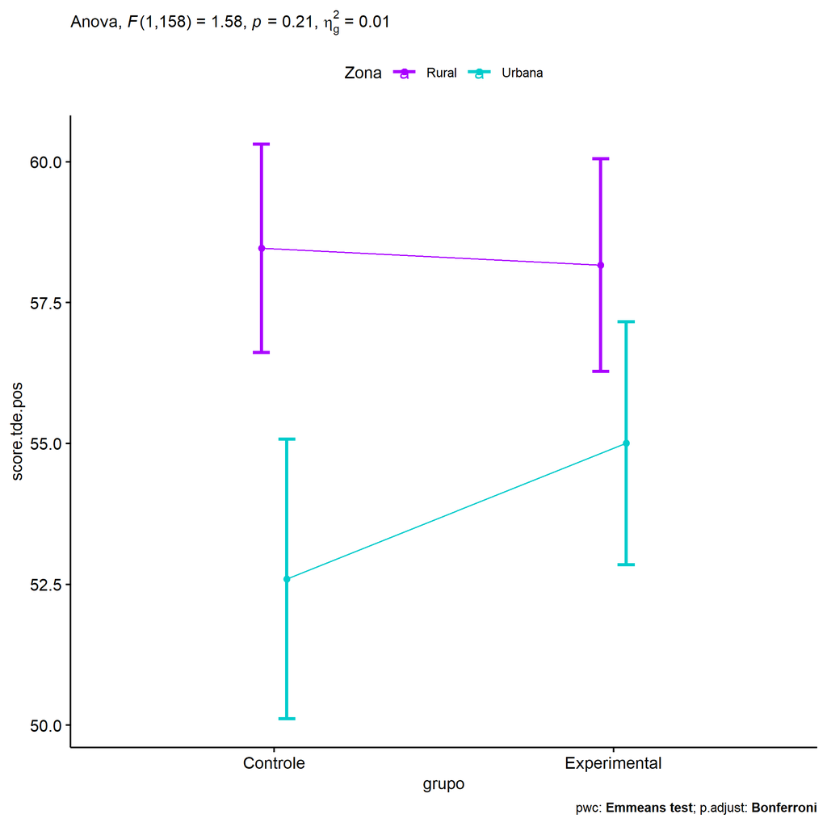

```r
if (!is.null(plots[["grupo"]]))
  plots[["grupo"]] + ggplot2::scale_color_manual(values = color[["Zona"]])
```

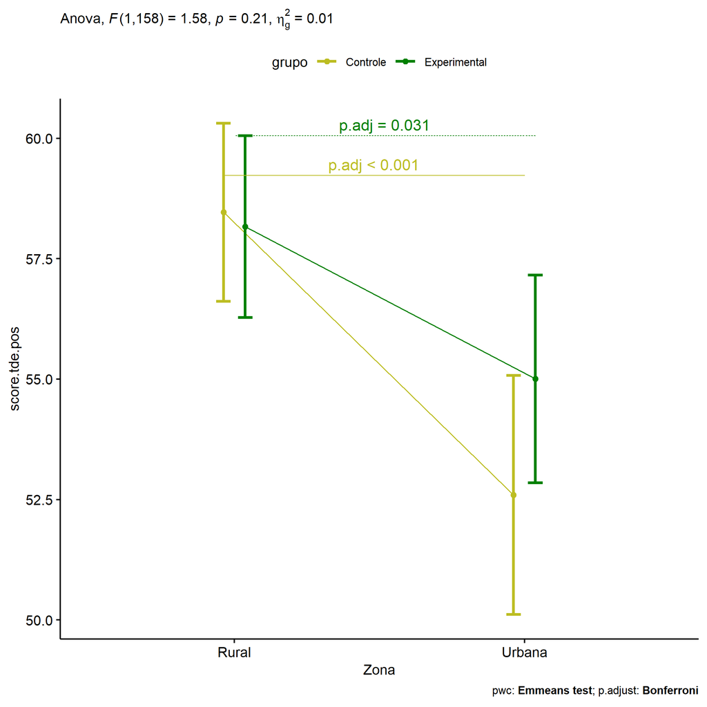

```r
if (!is.null(plots[["Zona"]]))
  plots[["Zona"]] + ggplot2::scale_color_manual(values = color[["grupo"]])
```

```r
plots <- twoWayAncovaBoxPlots(
  wdat, "score.tde.pos", c("grupo","Zona"), aov, pwcs, covar = "score.tde.pre",
  theme = "classic", color = color[["grupo:Zona"]],
  subtitle = which(aov$Effect == "grupo:Zona"))
```

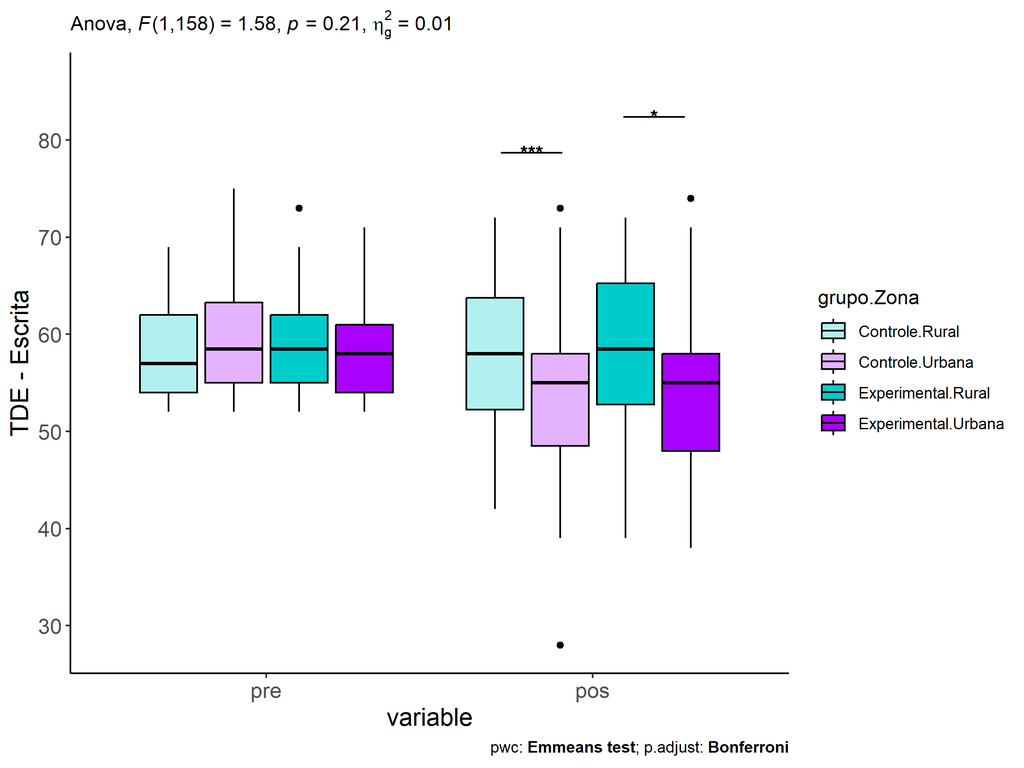

```r
plots[["grupo:Zona"]] + ggplot2::ylab("TDE - Escrita") + ggplot2::scale_x_discrete(labels=c('pre', 'pos'))
```

```r
plots <- twoWayAncovaBoxPlots(
  wdat.long, "score.tde", c("grupo","Zona"), aov, pwc.long, pre.post = "time",
  theme = "classic", color = color$prepost)
```

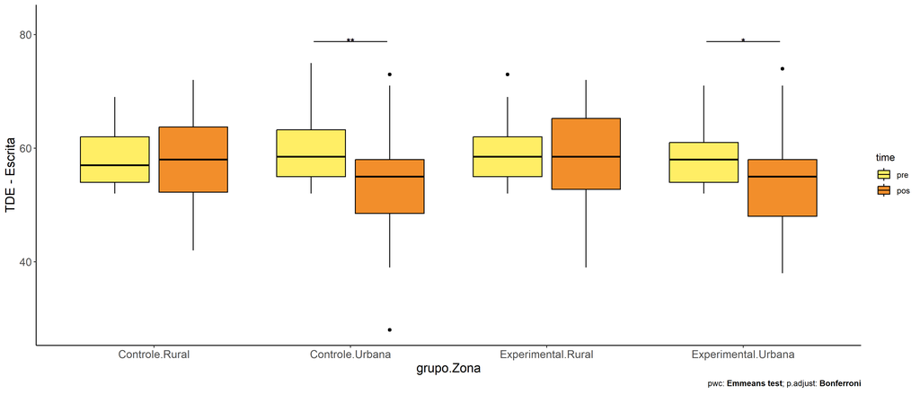

```r
plots[["grupo:Zona"]] + ggplot2::ylab("TDE - Escrita")
```

### Checking linearity assumption

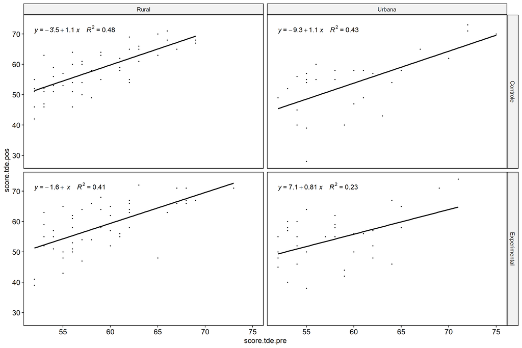

```r
ggscatter(wdat, x = "score.tde.pre", y = "score.tde.pos", size = 0.5,
          facet.by = c("grupo","Zona"), add = "reg.line")+
  stat_regline_equation(
    aes(label =  paste(..eq.label.., ..rr.label.., sep = "~~~~"))
  )
```

### Checking normality and homogeneity

```r
res <- augment(lm(score.tde.pos ~ score.tde.pre + grupo*Zona, data = wdat))
```

```r
shapiro_test(res$.resid)
```

```
## # A tibble: 1 × 3
##   variable   statistic p.value
##   <chr>          <dbl>   <dbl>
## 1 res$.resid     0.985  0.0695
```

```r
levene_test(res, .resid ~ grupo*Zona)
```

```
## # A tibble: 1 × 4
##     df1   df2 statistic     p
##   <int> <int>     <dbl> <dbl>
## 1     3   159      1.95 0.124
```

# ANCOVA and Pairwise for two factors **grupo:Cor.Raca**

## Without remove non-normal data

```r
pdat = remove_group_data(dat[!is.na(dat[["grupo"]]) & !is.na(dat[["Cor.Raca"]]),], "score.tde.pos", c("grupo","Cor.Raca"))

pdat.long <- rbind(pdat[,c("id","grupo","Cor.Raca")], pdat[,c("id","grupo","Cor.Raca")])
pdat.long[["time"]] <- c(rep("pre", nrow(pdat)), rep("pos", nrow(pdat)))
pdat.long[["time"]] <- factor(pdat.long[["time"]], c("pre","pos"))
pdat.long[["score.tde"]] <- c(pdat[["score.tde.pre"]], pdat[["score.tde.pos"]])

aov = anova_test(pdat, score.tde.pos ~ score.tde.pre + grupo*Cor.Raca)
laov[["grupo:Cor.Raca"]] <- get_anova_table(aov)
```

```r
pwcs <- list()
pwcs[["Cor.Raca"]] <- emmeans_test(
  group_by(pdat, grupo), score.tde.pos ~ Cor.Raca,
  covariate = score.tde.pre, p.adjust.method = "bonferroni")
pwcs[["grupo"]] <- emmeans_test(
  group_by(pdat, Cor.Raca), score.tde.pos ~ grupo,
  covariate = score.tde.pre, p.adjust.method = "bonferroni")

pwc <- plyr::rbind.fill(pwcs[["grupo"]], pwcs[["Cor.Raca"]])
pwc <- pwc[,c("grupo","Cor.Raca", colnames(pwc)[!colnames(pwc) %in% c("grupo","Cor.Raca")])]
```

```r
pwc.long <- emmeans_test(dplyr::group_by_at(pdat.long, c("grupo","Cor.Raca")),
                         score.tde ~ time,
                         p.adjust.method = "bonferroni")
lpwc[["grupo:Cor.Raca"]] <- plyr::rbind.fill(pwc, pwc.long)
```

```r
ds <- get.descriptives(pdat, "score.tde.pos", c("grupo","Cor.Raca"), covar = "score.tde.pre")
ds <- merge(ds[ds$variable != "score.tde.pre",],
            ds[ds$variable == "score.tde.pre", !colnames(ds) %in% c("variable")],
            by = c("grupo","Cor.Raca"), all.x = T, suffixes = c("", ".score.tde.pre"))
ds <- merge(get_emmeans(pwcs[["grupo"]]), ds, by = c("grupo","Cor.Raca"), suffixes = c(".emms", ""))
ds <- ds[,c("grupo","Cor.Raca","n","mean.score.tde.pre","se.score.tde.pre","mean","se","emmean","se.emms")]

colnames(ds) <- c("grupo","Cor.Raca", "N", paste0(c("M","SE")," (pre)"),
                  paste0(c("M","SE"), " (unadj)"), paste0(c("M", "SE"), " (adj)"))

lemms[["grupo:Cor.Raca"]] <- ds
```

## Computing ANCOVA and PairWise After removing non-normal data (OK)

```r
wdat = pdat

res = residuals(lm(score.tde.pos ~ score.tde.pre + grupo*Cor.Raca, data = wdat))
non.normal = getNonNormal(res, wdat$id, plimit = 0.05)

wdat = wdat[!wdat$id %in% non.normal,]

wdat.long <- rbind(wdat[,c("id","grupo","Cor.Raca")], wdat[,c("id","grupo","Cor.Raca")])
wdat.long[["time"]] <- c(rep("pre", nrow(wdat)), rep("pos", nrow(wdat)))
wdat.long[["time"]] <- factor(wdat.long[["time"]], c("pre","pos"))
wdat.long[["score.tde"]] <- c(wdat[["score.tde.pre"]], wdat[["score.tde.pos"]])


ldat[["grupo:Cor.Raca"]] = wdat

(non.normal)
```

```
##  [1] "P1128" "P1117" "P1018" "P908"  "P3021" "P3054" "P1104" "P3646" "P1149" "P1152" "P2961" "P3241"
## [13] "P1036" "P3228" "P3545" "P1118" "P3621" "P3657"
```

```r
aov = anova_test(wdat, score.tde.pos ~ score.tde.pre + grupo*Cor.Raca)
laov[["grupo:Cor.Raca"]] <- merge(get_anova_table(aov), laov[["grupo:Cor.Raca"]], by="Effect", suffixes = c("","'"))

(df = get_anova_table(aov))
```

```
## ANOVA Table (type II tests)
##
##           Effect DFn DFd         F        p p<.05      ges
## 1  score.tde.pre   1  71 56.476000 1.32e-10     * 4.43e-01
## 2          grupo   1  71  0.277000 6.00e-01       4.00e-03
## 3       Cor.Raca   1  71  0.037000 8.49e-01       5.16e-04
## 4 grupo:Cor.Raca   1  71  0.000478 9.83e-01       6.73e-06
```

| Effect | DFn | DFd | F | p | p<.05 | ges |
| --- | --- | --- | --- | --- | --- | --- |
| score.tde.pre | 1 | 71 | 56.476 | 0.000 | * | 0.443 |
| grupo | 1 | 71 | 0.277 | 0.600 |  | 0.004 |
| Cor.Raca | 1 | 71 | 0.037 | 0.849 |  | 0.001 |
| grupo:Cor.Raca | 1 | 71 | 0.000 | 0.983 |  | 0.000 |

```r
pwcs <- list()
pwcs[["Cor.Raca"]] <- emmeans_test(
  group_by(wdat, grupo), score.tde.pos ~ Cor.Raca,
  covariate = score.tde.pre, p.adjust.method = "bonferroni")
pwcs[["grupo"]] <- emmeans_test(
  group_by(wdat, Cor.Raca), score.tde.pos ~ grupo,
  covariate = score.tde.pre, p.adjust.method = "bonferroni")

pwc <- plyr::rbind.fill(pwcs[["grupo"]], pwcs[["Cor.Raca"]])
pwc <- pwc[,c("grupo","Cor.Raca", colnames(pwc)[!colnames(pwc) %in% c("grupo","Cor.Raca")])]
```

| grupo | Cor.Raca | term | .y. | group1 | group2 | df | statistic | p | p.adj | p.adj.signif |
| --- | --- | --- | --- | --- | --- | --- | --- | --- | --- | --- |
|  | Branca | score.tde.pre*grupo | score.tde.pos | Controle | Experimental | 71 | -0.308 | 0.759 | 0.759 | ns |
|  | Parda | score.tde.pre*grupo | score.tde.pos | Controle | Experimental | 71 | -0.429 | 0.669 | 0.669 | ns |
| Controle |  | score.tde.pre*Cor.Raca | score.tde.pos | Branca | Parda | 71 | -0.148 | 0.883 | 0.883 | ns |
| Experimental |  | score.tde.pre*Cor.Raca | score.tde.pos | Branca | Parda | 71 | -0.130 | 0.897 | 0.897 | ns |

```r
pwc.long <- emmeans_test(dplyr::group_by_at(wdat.long, c("grupo","Cor.Raca")),
                         score.tde ~ time,
                         p.adjust.method = "bonferroni")
lpwc[["grupo:Cor.Raca"]] <- merge(plyr::rbind.fill(pwc, pwc.long), lpwc[["grupo:Cor.Raca"]], by=c("grupo","Cor.Raca","term",".y.","group1","group2"), suffixes = c("","'"))
```

| grupo | Cor.Raca | term | .y. | group1 | group2 | df | statistic | p | p.adj | p.adj.signif |
| --- | --- | --- | --- | --- | --- | --- | --- | --- | --- | --- |
| Controle | Branca | time | score.tde | pre | pos | 144 | 0.782 | 0.435 | 0.435 | ns |
| Controle | Parda | time | score.tde | pre | pos | 144 | 1.147 | 0.253 | 0.253 | ns |
| Experimental | Branca | time | score.tde | pre | pos | 144 | 0.593 | 0.554 | 0.554 | ns |
| Experimental | Parda | time | score.tde | pre | pos | 144 | 0.728 | 0.468 | 0.468 | ns |

```r
ds <- get.descriptives(wdat, "score.tde.pos", c("grupo","Cor.Raca"), covar = "score.tde.pre")
ds <- merge(ds[ds$variable != "score.tde.pre",],
            ds[ds$variable == "score.tde.pre", !colnames(ds) %in% c("variable")],
            by = c("grupo","Cor.Raca"), all.x = T, suffixes = c("", ".score.tde.pre"))
ds <- merge(get_emmeans(pwcs[["grupo"]]), ds, by = c("grupo","Cor.Raca"), suffixes = c(".emms", ""))
ds <- ds[,c("grupo","Cor.Raca","n","mean.score.tde.pre","se.score.tde.pre","mean","se","emmean","se.emms")]

colnames(ds) <- c("grupo","Cor.Raca", "N", paste0(c("M","SE")," (pre)"),
                  paste0(c("M","SE"), " (unadj)"), paste0(c("M", "SE"), " (adj)"))

lemms[["grupo:Cor.Raca"]] <- merge(ds, lemms[["grupo:Cor.Raca"]], by=c("grupo","Cor.Raca"), suffixes = c("","'"))
```

| grupo | Cor.Raca | N | M (pre) | SE (pre) | M (unadj) | SE (unadj) | M (adj) | SE (adj) |
| --- | --- | --- | --- | --- | --- | --- | --- | --- |
| Controle | Branca | 10 | 60.800 | 1.298 | 58.600 | 2.500 | 56.653 | 1.790 |
| Controle | Parda | 27 | 57.259 | 0.782 | 55.296 | 1.077 | 56.967 | 1.100 |
| Experimental | Branca | 13 | 61.385 | 1.542 | 59.923 | 2.232 | 57.379 | 1.589 |
| Experimental | Parda | 26 | 58.615 | 1.070 | 57.346 | 1.684 | 57.632 | 1.099 |

### Plots for ancova

```r
plots <- twoWayAncovaPlots(
  wdat, "score.tde.pos", c("grupo","Cor.Raca"), aov, pwcs, addParam = c("mean_se"),
  font.label.size=10, step.increase=0.05, p.label="p.adj",
  subtitle = which(aov$Effect == "grupo:Cor.Raca"))
```

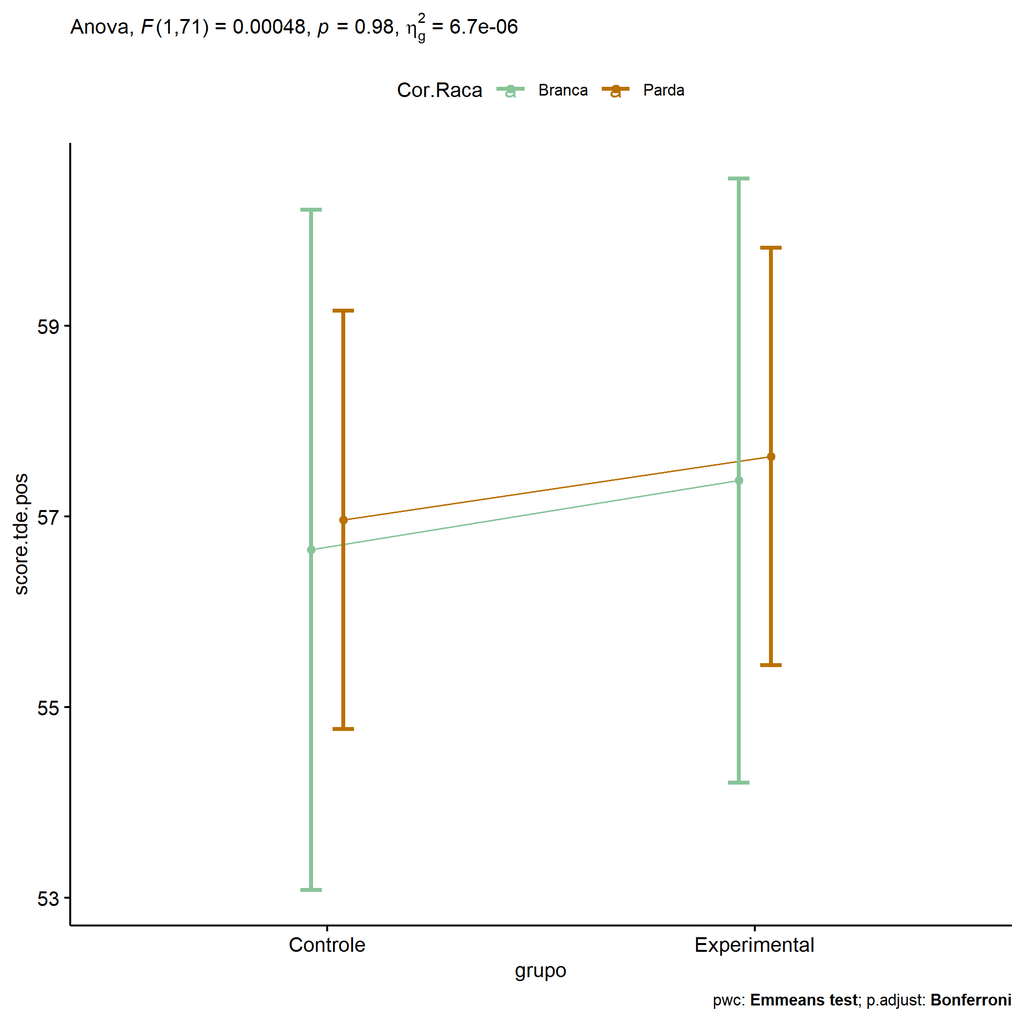

```r
if (!is.null(plots[["grupo"]]))
  plots[["grupo"]] + ggplot2::scale_color_manual(values = color[["Cor.Raca"]])
```

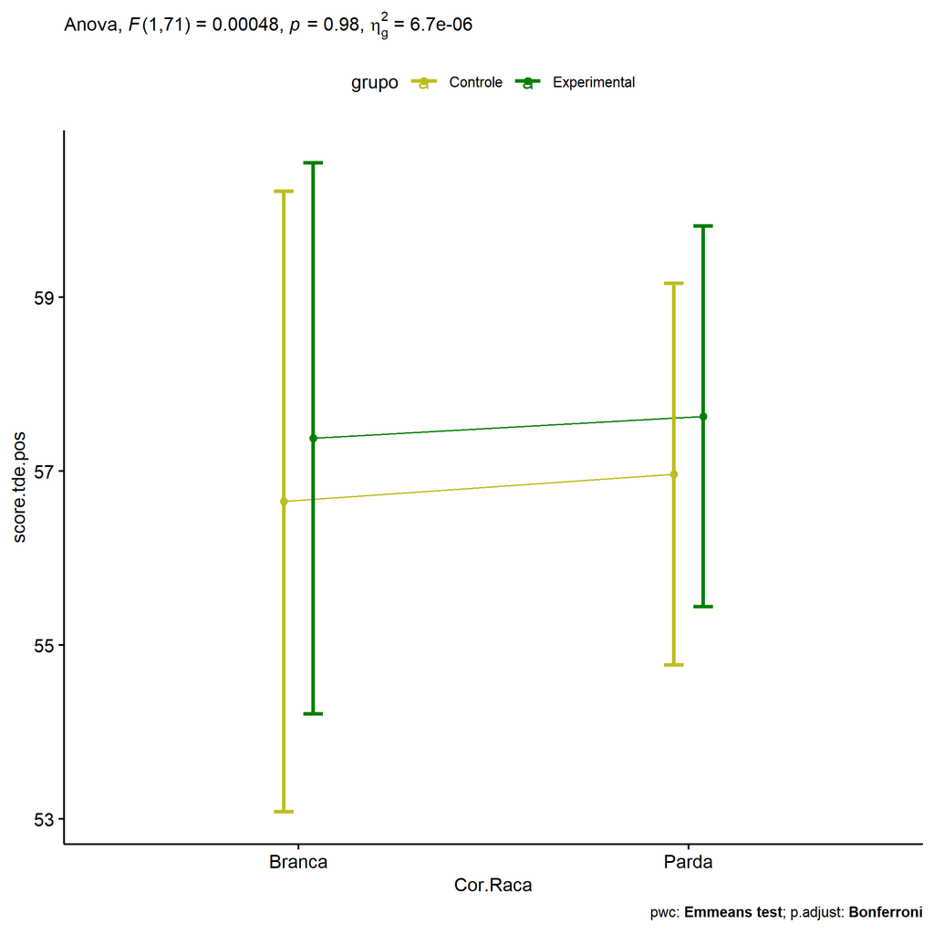

```r
if (!is.null(plots[["Cor.Raca"]]))
  plots[["Cor.Raca"]] + ggplot2::scale_color_manual(values = color[["grupo"]])
```

```r
plots <- twoWayAncovaBoxPlots(
  wdat, "score.tde.pos", c("grupo","Cor.Raca"), aov, pwcs, covar = "score.tde.pre",
  theme = "classic", color = color[["grupo:Cor.Raca"]],
  subtitle = which(aov$Effect == "grupo:Cor.Raca"))
```

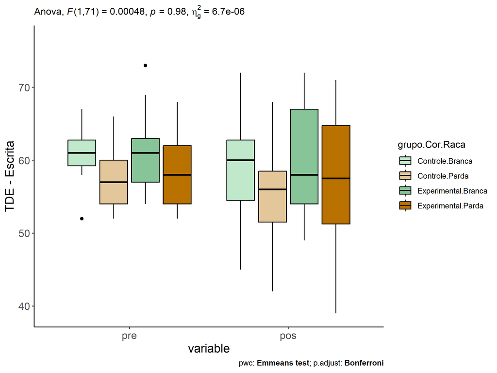

```r
plots[["grupo:Cor.Raca"]] + ggplot2::ylab("TDE - Escrita") + ggplot2::scale_x_discrete(labels=c('pre', 'pos'))
```

```r
plots <- twoWayAncovaBoxPlots(
  wdat.long, "score.tde", c("grupo","Cor.Raca"), aov, pwc.long, pre.post = "time",
  theme = "classic", color = color$prepost)
```

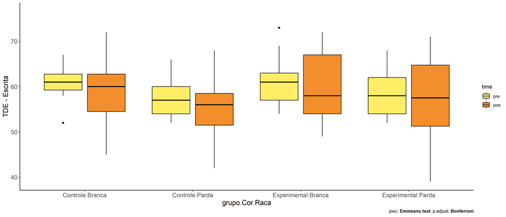

```r
plots[["grupo:Cor.Raca"]] + ggplot2::ylab("TDE - Escrita")
```

### Checking linearity assumption

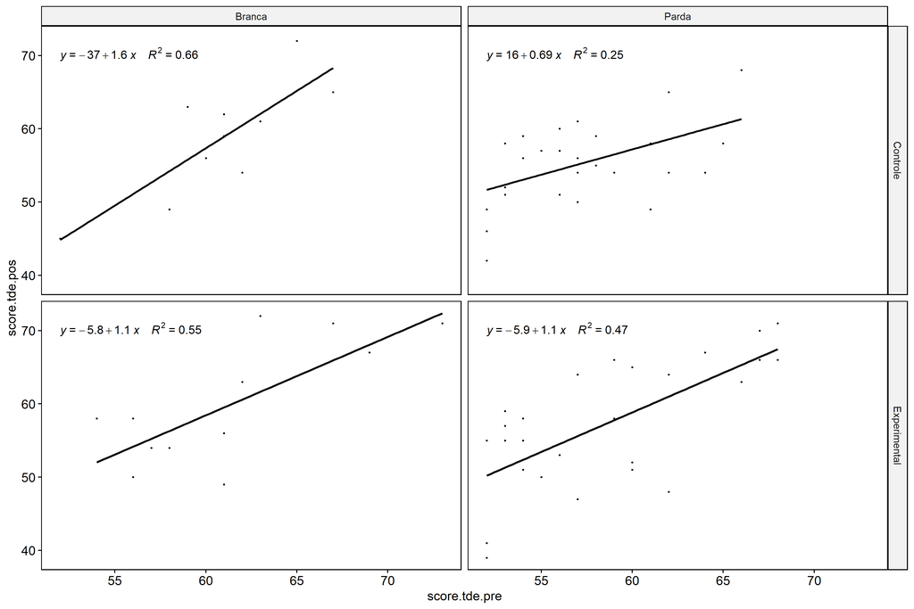

```r
ggscatter(wdat, x = "score.tde.pre", y = "score.tde.pos", size = 0.5,
          facet.by = c("grupo","Cor.Raca"), add = "reg.line")+
  stat_regline_equation(
    aes(label =  paste(..eq.label.., ..rr.label.., sep = "~~~~"))
  )
```

### Checking normality and homogeneity

```r
res <- augment(lm(score.tde.pos ~ score.tde.pre + grupo*Cor.Raca, data = wdat))
```

```r
shapiro_test(res$.resid)
```

```
## # A tibble: 1 × 3
##   variable   statistic p.value
##   <chr>          <dbl>   <dbl>
## 1 res$.resid     0.976   0.149
```

```r
levene_test(res, .resid ~ grupo*Cor.Raca)
```

```
## # A tibble: 1 × 4
##     df1   df2 statistic     p
##   <int> <int>     <dbl> <dbl>
## 1     3    72     0.632 0.597
```

# ANCOVA and Pairwise for two factors **grupo:Serie**

## Without remove non-normal data

```r
pdat = remove_group_data(dat[!is.na(dat[["grupo"]]) & !is.na(dat[["Serie"]]),], "score.tde.pos", c("grupo","Serie"))

pdat.long <- rbind(pdat[,c("id","grupo","Serie")], pdat[,c("id","grupo","Serie")])
pdat.long[["time"]] <- c(rep("pre", nrow(pdat)), rep("pos", nrow(pdat)))
pdat.long[["time"]] <- factor(pdat.long[["time"]], c("pre","pos"))
pdat.long[["score.tde"]] <- c(pdat[["score.tde.pre"]], pdat[["score.tde.pos"]])

aov = anova_test(pdat, score.tde.pos ~ score.tde.pre + grupo*Serie)
laov[["grupo:Serie"]] <- get_anova_table(aov)
```

```r
pwcs <- list()
pwcs[["Serie"]] <- emmeans_test(
  group_by(pdat, grupo), score.tde.pos ~ Serie,
  covariate = score.tde.pre, p.adjust.method = "bonferroni")
pwcs[["grupo"]] <- emmeans_test(
  group_by(pdat, Serie), score.tde.pos ~ grupo,
  covariate = score.tde.pre, p.adjust.method = "bonferroni")

pwc <- plyr::rbind.fill(pwcs[["grupo"]], pwcs[["Serie"]])
pwc <- pwc[,c("grupo","Serie", colnames(pwc)[!colnames(pwc) %in% c("grupo","Serie")])]
```

```r
pwc.long <- emmeans_test(dplyr::group_by_at(pdat.long, c("grupo","Serie")),
                         score.tde ~ time,
                         p.adjust.method = "bonferroni")
lpwc[["grupo:Serie"]] <- plyr::rbind.fill(pwc, pwc.long)
```

```r
ds <- get.descriptives(pdat, "score.tde.pos", c("grupo","Serie"), covar = "score.tde.pre")
ds <- merge(ds[ds$variable != "score.tde.pre",],
            ds[ds$variable == "score.tde.pre", !colnames(ds) %in% c("variable")],
            by = c("grupo","Serie"), all.x = T, suffixes = c("", ".score.tde.pre"))
ds <- merge(get_emmeans(pwcs[["grupo"]]), ds, by = c("grupo","Serie"), suffixes = c(".emms", ""))
ds <- ds[,c("grupo","Serie","n","mean.score.tde.pre","se.score.tde.pre","mean","se","emmean","se.emms")]

colnames(ds) <- c("grupo","Serie", "N", paste0(c("M","SE")," (pre)"),
                  paste0(c("M","SE"), " (unadj)"), paste0(c("M", "SE"), " (adj)"))

lemms[["grupo:Serie"]] <- ds
```